# We Rate Dogs

### An insightful look on the viral trend on twitter

**WeRateDogs** is a twitter account started by Nelson, a golf management major from Campbell University in Buies Creek, North Carolina. The account rates people's dogs with a humorous comment about the dog and it went viral in 2015. It became so popular that by December 2018, the account had nearly 7.6 million followers!! Nelson also released a book based on the Twitter account, *#WeRateDogs: The Most Hilarious and Adorable Pups You’ve Ever Seen*

Owing to the popularity of this trend, we have decided to gather some data and provide few small interesting insights about this trend. To achieve this, we have extracted the tweet data from twitter's database and also used a neural network to identify the dog breed from each tweet!! Here are some of the insights we could gather that you might quite interesting

### Most favourite breed of dogs

We have data about every tweet and also have image predictions of each dog. After assessing and cleaning the data, we can now figure out which breed of dog is most loved by people!

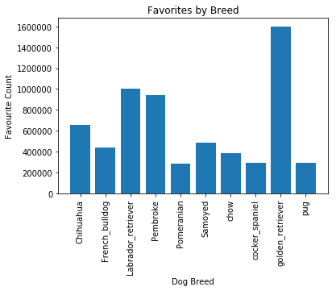

The above bar plot has the top 10 favourite breeds. From the above plot, it can be seen that the Golden retriever is the most loved breed of dog! It leads the 2nd most favourite breed, the Labrador by a large number. The labrador is followed closely by Pembroke.

### Most popular names of dogs

It would also be interesting to see what is the most popular name in the dog community. Most users tweet the name of the dog as well and we have gathered this information and have some interesting results below

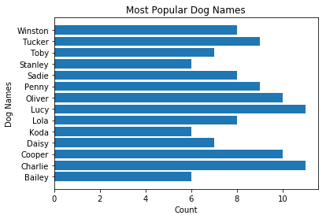

So from the above horizontal bar plot we can see that Lucy and Charlie are the most popular dog names!! Cooper and Oliver are also not left far behind!

### Retweet Count and Favourite Count

We also have information about the count of retweets of each tweet as well as the number of times a tweet was liked. We can now answer the question if the most retweeted tweets are also the most favorite ones?

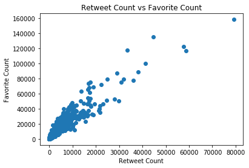

```
Correlation between retweet count and favourite count is 0.927121035314
```

So we can see from the scatter plot above that the retweets and favourites are positively correlated, which means if a tweet is liked more, it is also retweeted more!

### Bonus!

This below is the picture of the most popular dog in the WeRateDogs community. He was liked by 158519 people and the tweet was retweeted 79115 times! Is'int he adorable!?

[figure not shown]